# Part II - The Prosper Loan Data Investigation and Findings

## by Taiwo Oyerinde

## Investigation Overview

For this presentation, we shall be systematically investigating prosper loan data key features about the borrowers(Employment status and Occupation), factors that make them eligible for the loan and their tendency to pay back.

## Dataset Overview

The original dataset used was provided in the Udacity Classroom. It contains 113,937 loans with 81 variables on each loan listing. But for this investigation, a subset of the original dataset that contains 20 variables of interest will be used.

## Distribution Of Borrowers' Employment Status

Borrowers' employment status were distributed across a set of statuses but a greater percentage identified as employed and full-time. This is quite surprising as I earlier thought that most borrowers would identify as self-employed.

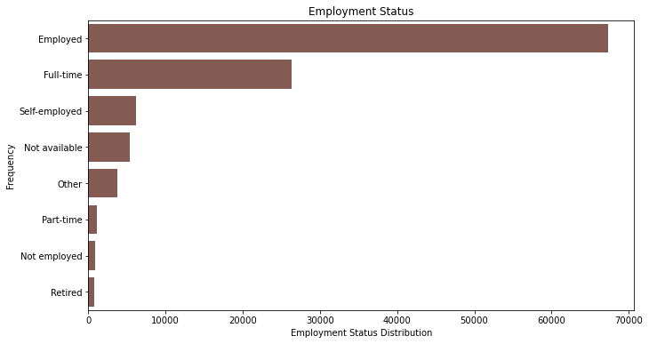

## Distribution Of Borrowers' Occupation

Although a very significant number of borrowers didn't specify their occupation, Borrowers who identified as professionals were the next highest. The top 10 occupations of borrowers are shown in the next slide

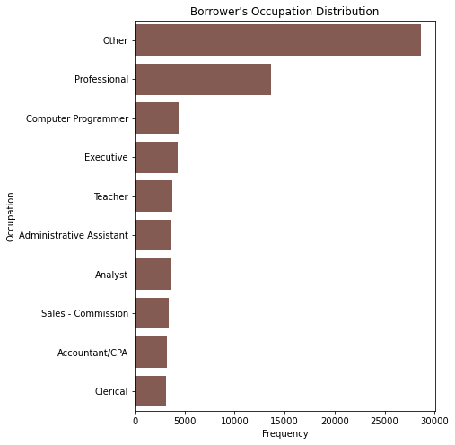

## Borrowers' Income Range Distribution

As will be displayed in the next slide, majority of the borrowers earn no less than $25,0000

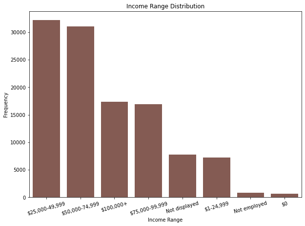

## Relationship between the Borrowers' Stated Monthly Income, Annual Percentage Rate Monthly loan payment and loan original amount

A heatmap was created to show the correlation amongst the above stated variables and the following were noted;

1. As expected, monthly loan payment and loan original amount were the most positively correlated.
2. A good number of borrowers with higher monthly incomes were the ones with higher loan monthly payments.

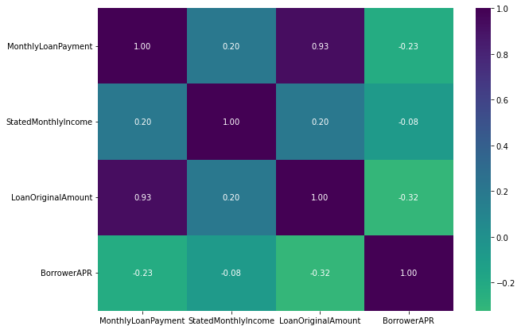

## Relationship between Loan Term and Loan Original Amount

Here, we illustrated the relationship using a box plot and it was discovered that the higher the loan amount taken, the longer the time for repayment

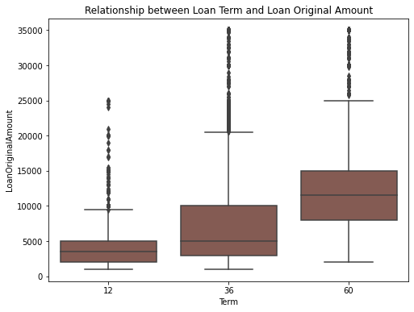

## Relationship between Home Ownership, Loan status and Verifiable Income

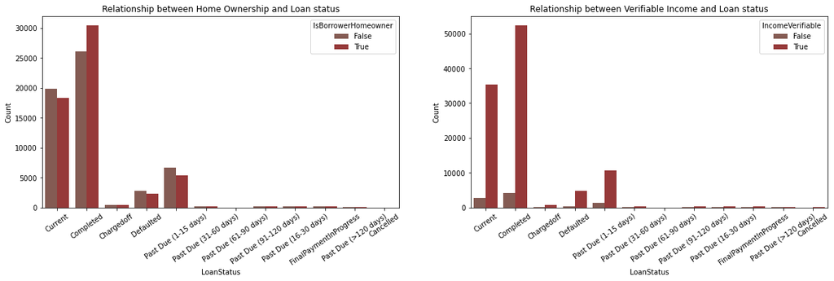